# Module 1

Neha Parulekar

January 25, 2016

## M1L2 Homework

This homework assignment focuses on Probability Distributions.

- Replicate and plot the fat-tailed Cauchy distributions from https://en.wikipedia.org/wiki/Cauchy_distribution

To run the code in you may need additional packages.

If necessary install `ggplot2` package.

`install.packages("ggplot2");`install.packages(“reshape”);

```r
require(ggplot2)
require(reshape)
 trails <- 3333
 Rcauchy <- data.frame(A=rcauchy(n=trails, location=0, scale=0.5),
B=rcauchy(n=trails, location=0, scale=1),  C=rcauchy(n=trails, location=0, scale=2), D=rcauchy(n=trails, location=-2, scale =1))

head(Rcauchy)
```

```
##              A           B             C          D
## 1  2.201323329  -6.2561346  -0.005613433 -1.7826483
## 2  0.404312458  -0.3043093  -1.048131678 -2.0473659
## 3  0.310786128   1.6744700  -8.962879282  2.1771725
## 4  0.862278025 -11.9832092 -11.041204310 -2.2460367
## 5  0.295304246  -1.2317903  -0.332126218 -2.2779046
## 6 -0.001869991   0.3788899   9.381411675 -0.7669493
```

```r
summary(Rcauchy)
```

```
##        A                  B                    C
##  Min.   :-817.790   Min.   :-2131.4987   Min.   :-14352.775
##  1st Qu.:  -0.468   1st Qu.:   -0.8858   1st Qu.:    -2.141
##  Median :   0.014   Median :    0.0504   Median :    -0.047
##  Mean   :   2.945   Mean   :    0.1703   Mean   :    -7.312
##  3rd Qu.:   0.561   3rd Qu.:    1.1172   3rd Qu.:     1.973
##  Max.   :8336.772   Max.   : 1836.5905   Max.   :   704.858
##        D
##  Min.   :-1223.0281
##  1st Qu.:   -3.0138
##  Median :   -2.0123
##  Mean   :   -0.6346
##  3rd Qu.:   -1.0177
##  Max.   : 1943.2846
```

```r
library(reshape)
rnd <- melt(data=Rcauchy)
```

```
## Using  as id variables
```

```r
## No id variables; using all as measure variables

head(rnd)
```

```
##   variable        value
## 1        A  2.201323329
## 2        A  0.404312458
## 3        A  0.310786128
## 4        A  0.862278025
## 5        A  0.295304246
## 6        A -0.001869991
```

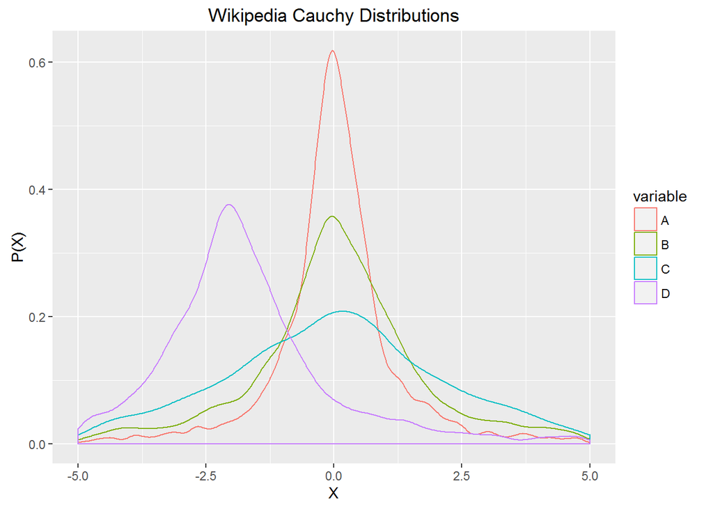

```r
library(ggplot2)
ggplot(rnd, aes(x=value)) + geom_density(aes(group=variable,color=variable)) + labs(title="Wikipedia Cauchy Distributions", y="P(X)", x="X") + xlim(-5,5)
```

- Load the file M01_Lesson_02_Q1.csv
- Answer the following questions for the data in each column:
  - How is the data distributed?
  - What are the summary statistics?
  - Are there anomalies/outliers?
  - Try to regenerate the data in each column.
  - Plot your regenerated data versus the original data using a faceted graph. How does it compare?

```r
setwd("C:/Users/Neha/Desktop")
dataset <- read.csv("M01_Lesson_02_Q1.csv")
head(dataset)
```

```
##   X         A          B C  D         E
## 1 1  8.257164 -0.6560755 6  8 309.67242
## 2 2 10.557378 -0.7158294 7  8 301.74808
## 3 3  8.744211  0.7996107 7  5 158.75132
## 4 4  6.555028  1.5832173 6 10 293.42639
## 5 5  9.362121  1.0272024 7  8 261.03700
## 6 6  9.020671  0.7197130 7 12  80.01178
```

**Answers**

1. How is the data distributed?

Distribution of a single variable can be showed by density plots and histograms.

**A**

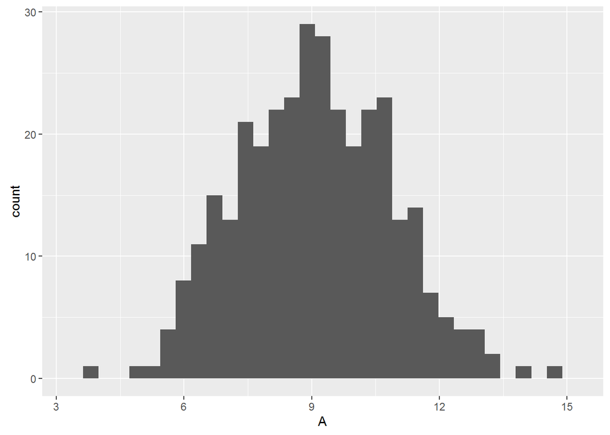

```r
qplot(A, data = dataset, geom = "histogram")
```

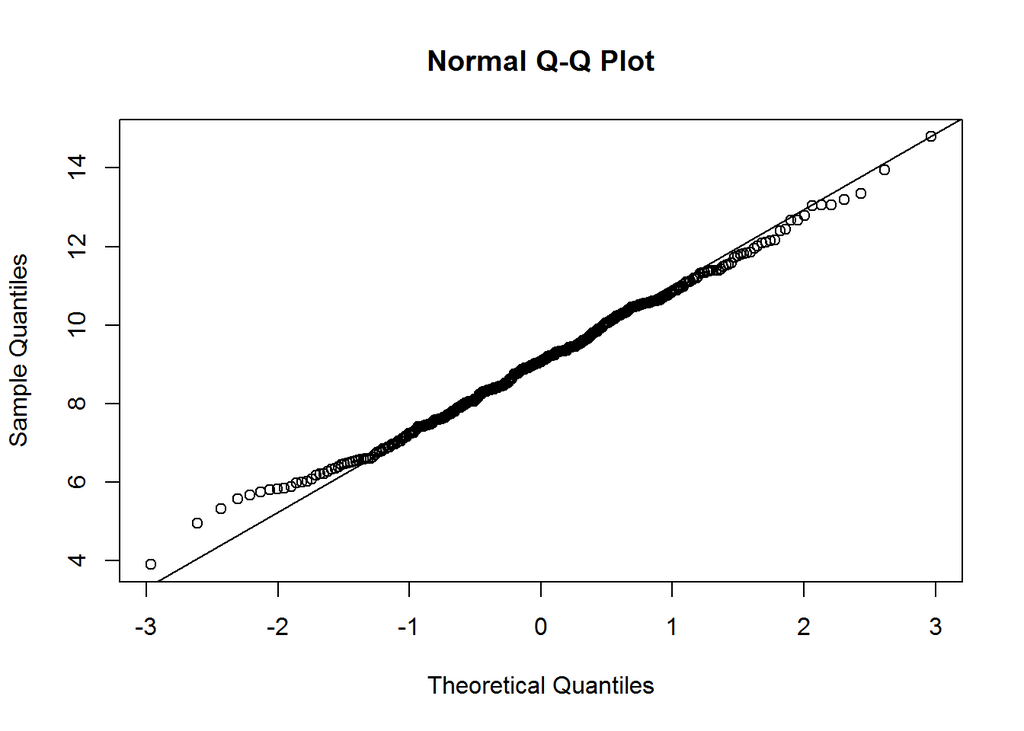

```r
qqnorm(dataset$A)
qqline(dataset$A)
```

*From the plots above we can say that the data is normally distributed*

2. What are the summary statistics?

```r
summary(dataset$A)
```

```
##    Min. 1st Qu.  Median    Mean 3rd Qu.    Max.
##   3.902   7.793   9.072   9.079  10.390  14.790
```

3. Are there anomalies/outliers?
- There are outliers at 4 and between 13-14

**B**

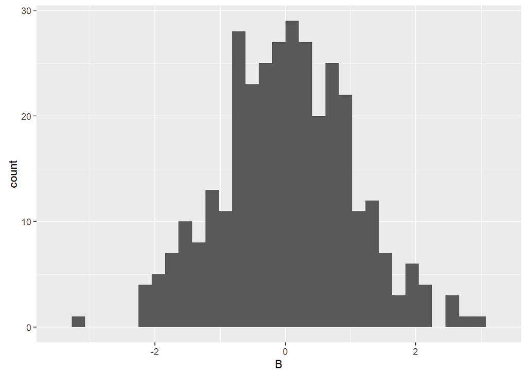

```r
qplot(B, data = dataset, geom = "histogram")
```

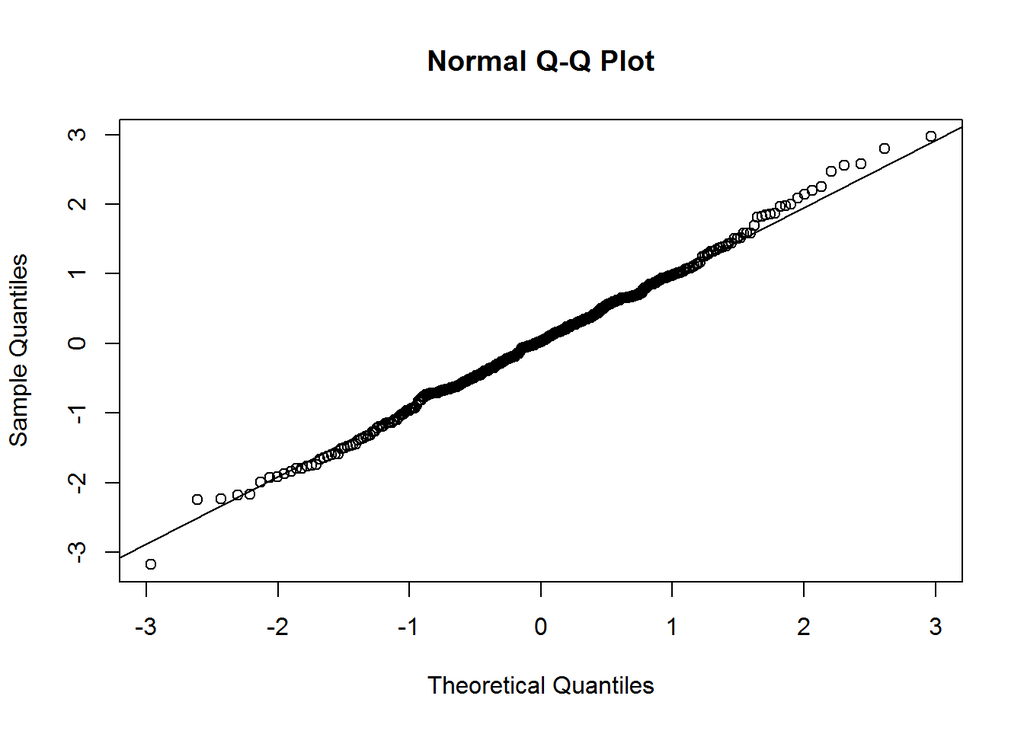

```r
qqnorm(dataset$B)
qqline(dataset$B)
```

*From the plots above we can say that the data is normally distributed*

2. What are the summary statistics?

```r
summary(dataset$B)
```

```
##     Min.  1st Qu.   Median     Mean  3rd Qu.     Max.
## -3.17600 -0.63200  0.03412  0.03063  0.67030  2.96900
```

3. Are there anomalies/outliers?
- There are outliers at -3 and beyond 2

**C**

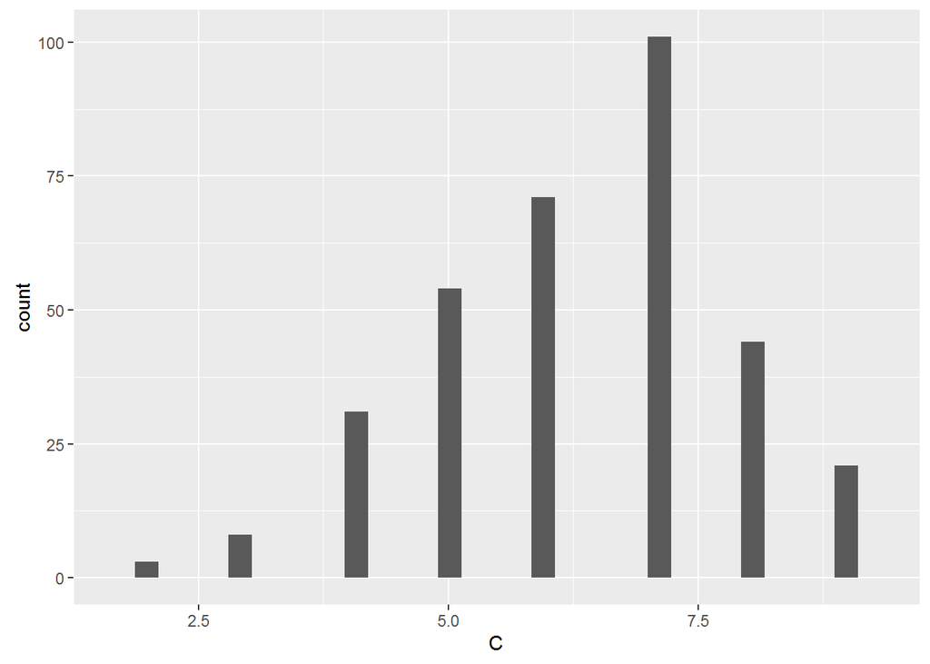

```r
qplot(C, data = dataset, geom = "histogram")
```

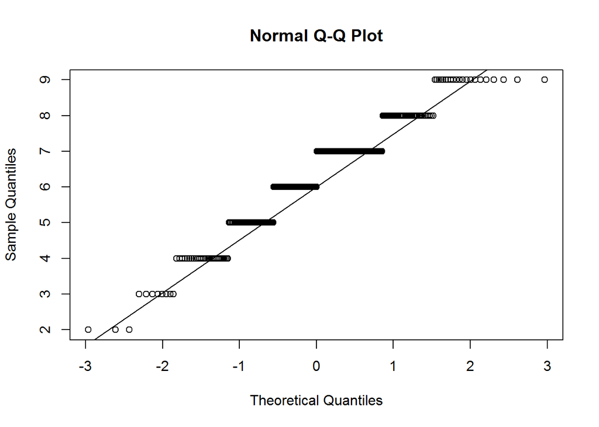

```r
qqnorm(dataset$C)
qqline(dataset$C)
```

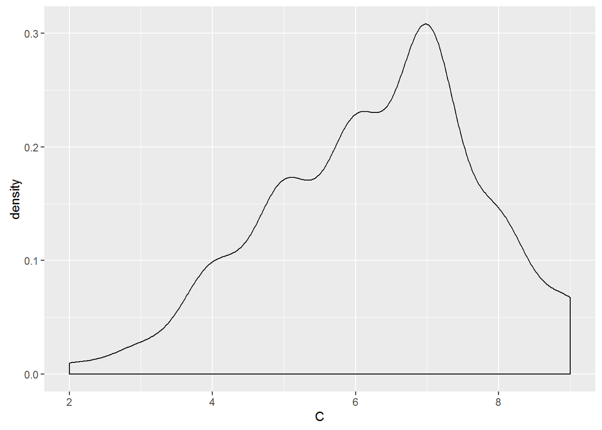

```r
ggplot(dataset)+aes(x=C) + geom_density()
```

2. What are the summary statistics?

```r
summary(dataset$C)
```

```
##    Min. 1st Qu.  Median    Mean 3rd Qu.    Max.
##     2.0     5.0     6.0     6.3     7.0     9.0
```

3. Are there anomalies/outliers?
- There are no outliers.

**D**

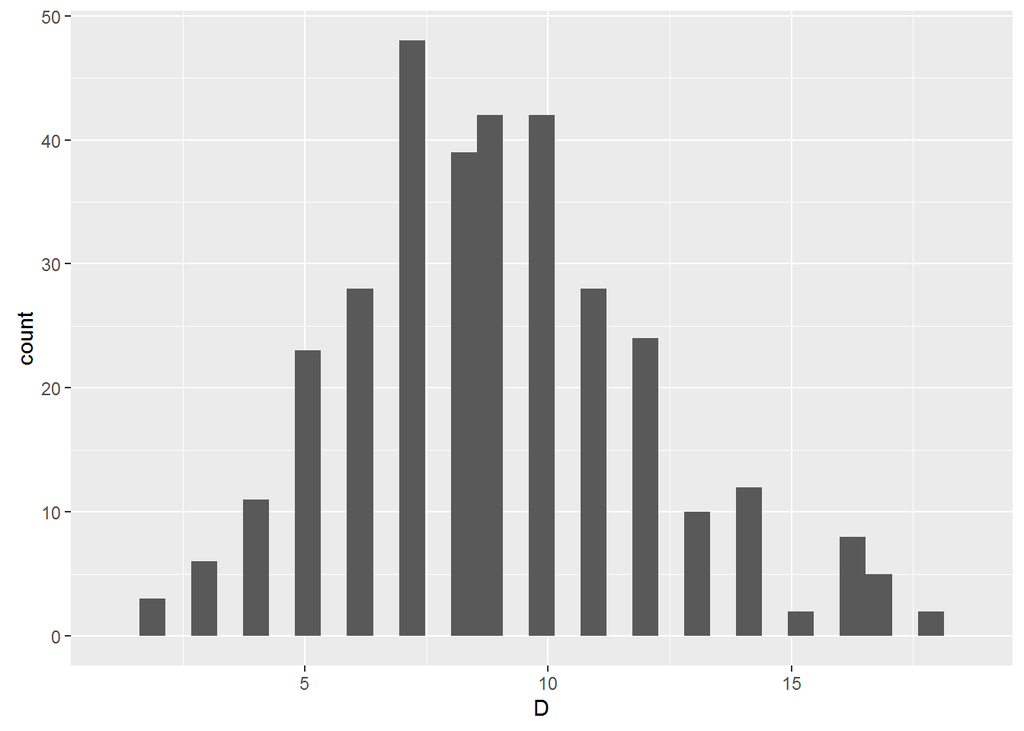

```r
qplot(D, data = dataset, geom = "histogram")
```

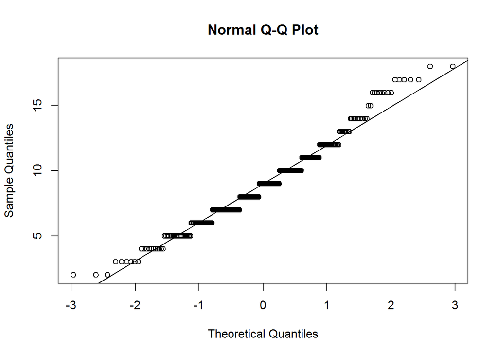

```r
qqnorm(dataset$D)
qqline(dataset$D)
```

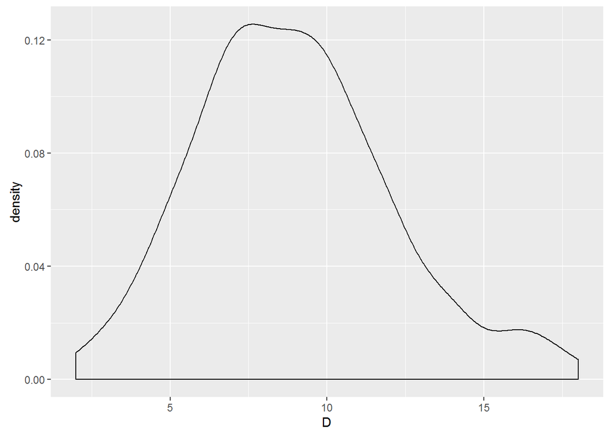

```r
ggplot(dataset)+aes(x=D) + geom_density()
```

*From the plots above we can say that the data is distributed binomially from right skew and integer values*

2. What are the summary statistics?

```r
summary(dataset$D)
```

```
##    Min. 1st Qu.  Median    Mean 3rd Qu.    Max.
##   2.000   7.000   9.000   8.919  11.000  18.000
```

3. Are there anomalies/outliers?
- There are no outliers.

**E**

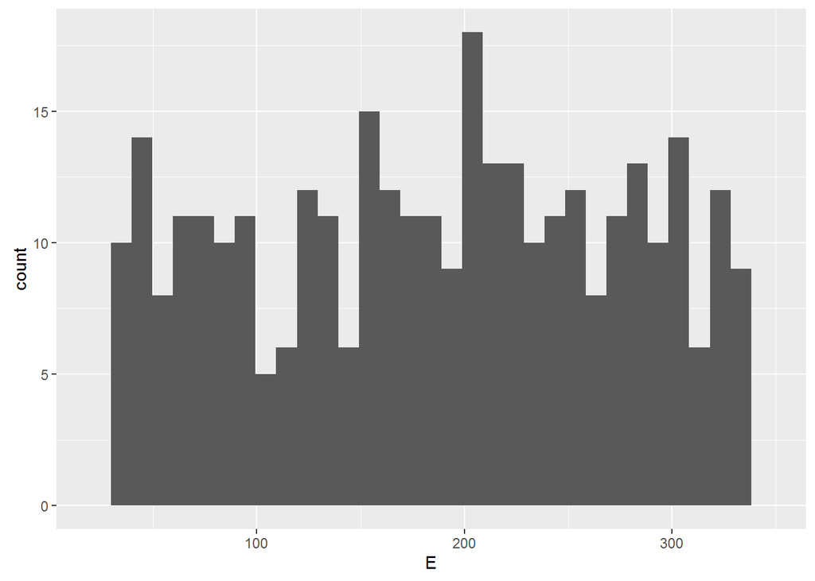

```r
qplot(E, data = dataset, geom = "histogram")
```

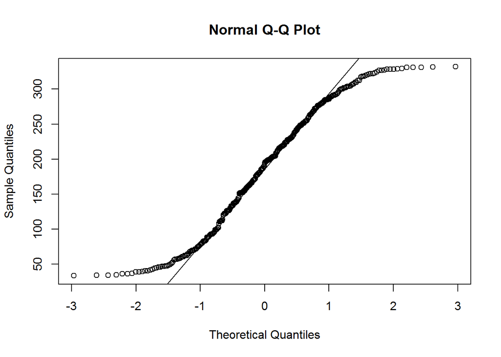

```r
qqnorm(dataset$E)
qqline(dataset$E)
```

- From the plots above we can say that the data is distributed uniformaly*
2. What are the summary statistics?

```r
summary(dataset$E)
```

```
##    Min. 1st Qu.  Median    Mean 3rd Qu.    Max.
##   33.52  112.30  194.10  185.90  258.40  331.80
```

3. Are there anomalies/outliers?
- There are no outliers.
- Try to regenerate the data in each column.

```r
set.seed(100)
trails <- 333
RA <- rnorm(n=trails, mean=9.079, sd=2.89)
RB <- rnorm(n=trails, mean=0.030, sd=1.29)
RC <- rbinom(n=trails, size=9, p=0.7)
RD <- rbinom(n=trails, size=18,p=0.11)
min<-33.52
max<-331.80
RE <- runif(trails, min, max+1)
regdata<- data.frame(RA,RB,RC,RD,RE)
summary(regdata)
```

```
##        RA                RB                 RC              RD
##  Min.   : 0.3488   Min.   :-4.25381   Min.   :3.000   Min.   :0.00
##  1st Qu.: 7.5464   1st Qu.:-0.86884   1st Qu.:5.000   1st Qu.:1.00
##  Median : 9.0091   Median : 0.01252   Median :6.000   Median :2.00
##  Mean   : 9.0949   Mean   :-0.02447   Mean   :6.204   Mean   :1.97
##  3rd Qu.:10.8884   3rd Qu.: 0.88109   3rd Qu.:7.000   3rd Qu.:3.00
##  Max.   :16.9626   Max.   : 4.29235   Max.   :9.000   Max.   :7.00
##        RE
##  Min.   : 33.85
##  1st Qu.:102.87
##  Median :175.94
##  Mean   :177.60
##  3rd Qu.:245.16
##  Max.   :332.25
```

- Plot your regenerated data versus the original data using a faceted graph. How does it compare?

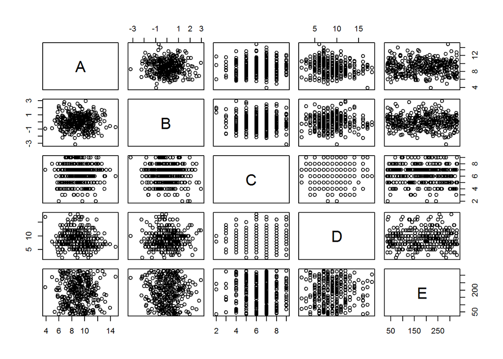

```r
pairs(dataset[,2:6])
```

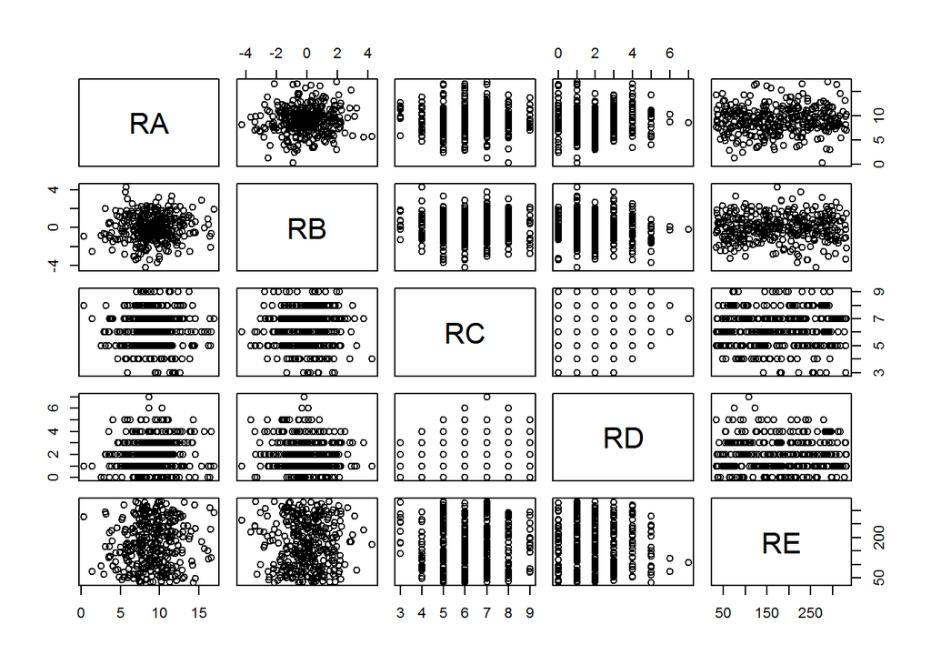

```r
pairs(regdata[,1:5])
```